# R Notebook

```r
library(tidyverse)
```

```r
getwd()
```

```
[1] "/Users/ellieking/Documents/give-depts-data/R"
```

```r
accurate_p <- read_csv("../DATA/accurate_proportions.csv")
```

```r
spec(accurate_p)
```

```r
y <- cbind(accurate_p$is_this_useful_yes, accurate_p$is_this_useful_no)
```

```r
model <- glm(y~accurate_p$spelling_grammar, family='binomial')
model1 <- glm(y~log(accurate_p$spelling_grammar +1), family='binomial')
summary(model)
```

```
Call:
glm(formula = y ~ accurate_p$spelling_grammar, family = "binomial")

Deviance Residuals:
    Min       1Q   Median       3Q      Max
-79.169   -5.936   -0.353    4.854   66.491

Coefficients:
                              Estimate Std. Error z value Pr(>|z|)
(Intercept)                   0.126942   0.003477   36.51   <2e-16 ***
accurate_p$spelling_grammar -12.534342   0.271833  -46.11   <2e-16 ***
---
Signif. codes:  0 ‘***’ 0.001 ‘**’ 0.01 ‘*’ 0.05 ‘.’ 0.1 ‘ ’ 1

(Dispersion parameter for binomial family taken to be 1)

    Null deviance: 72824  on 574  degrees of freedom
Residual deviance: 69873  on 573  degrees of freedom
AIC: 73267

Number of Fisher Scoring iterations: 4
```

There are proportionally more yes-useful responses at lower spelling_grammar scores.

We can see if log transofmration of the explanatory var reduces the residual deviance below 69873

```r
summary(model1)
```

```
Call:
glm(formula = y ~ log(accurate_p$spelling_grammar + 1), family = "binomial")

Deviance Residuals:
    Min       1Q   Median       3Q      Max
-79.158   -5.922   -0.331    4.851   66.398

Coefficients:
                                       Estimate Std. Error z value Pr(>|z|)
(Intercept)                            0.128374   0.003481   36.88   <2e-16 ***
log(accurate_p$spelling_grammar + 1) -13.474868   0.289376  -46.56   <2e-16 ***
---
Signif. codes:  0 ‘***’ 0.001 ‘**’ 0.01 ‘*’ 0.05 ‘.’ 0.1 ‘ ’ 1

(Dispersion parameter for binomial family taken to be 1)

    Null deviance: 72824  on 574  degrees of freedom
Residual deviance: 69832  on 573  degrees of freedom
AIC: 73226

Number of Fisher Scoring iterations: 4
```

There is a bit of an improement.

```r
model2 <- glm(y~log(accurate_p$spelling_grammar+1)+
                log(accurate_p$errors+1)+
                log(accurate_p$style+1)+
                log(accurate_p$number_of_pdfs+1)+
                log(accurate_p$number_of_word_files+1)+
                as.factor(accurate_p$document_type)+
                log(accurate_p$string_length+1)+
                log(accurate_p$sentence_count+1)+
                log(accurate_p$word_count+1),
              family='binomial')
summary(model2)
```

```
Call:
glm(formula = y ~ log(accurate_p$spelling_grammar + 1) + log(accurate_p$errors +
    1) + log(accurate_p$style + 1) + log(accurate_p$number_of_pdfs +
    1) + log(accurate_p$number_of_word_files + 1) + as.factor(accurate_p$document_type) +
    log(accurate_p$string_length + 1) + log(accurate_p$sentence_count +
    1) + log(accurate_p$word_count + 1), family = "binomial")

Deviance Residuals:
    Min       1Q   Median       3Q      Max
-44.952   -4.940    0.000    4.148   45.532

Coefficients:
                                                             Estimate Std. Error z value Pr(>|z|)
(Intercept)                                                  1.643421   0.194334   8.457  < 2e-16 ***
log(accurate_p$spelling_grammar + 1)                        -4.461369   0.411508 -10.842  < 2e-16 ***
log(accurate_p$errors + 1)                                  19.923384   0.840852  23.694  < 2e-16 ***
log(accurate_p$style + 1)                                   -5.691536   0.452903 -12.567  < 2e-16 ***
log(accurate_p$number_of_pdfs + 1)                           0.116963   0.035802   3.267 0.001087 **
log(accurate_p$number_of_word_files + 1)                    -1.195157   0.276674  -4.320 1.56e-05 ***
as.factor(accurate_p$document_type)about_our_services        0.091343   0.228444   0.400 0.689267
as.factor(accurate_p$document_type)answer                    0.126248   0.188373   0.670 0.502728
as.factor(accurate_p$document_type)calendar                 -1.440422   0.202284  -7.121 1.07e-12 ***
as.factor(accurate_p$document_type)case_study                1.223713   0.250846   4.878 1.07e-06 ***
as.factor(accurate_p$document_type)complaints_procedure     -0.947795   0.267267  -3.546 0.000391 ***
as.factor(accurate_p$document_type)completed_transaction    -0.885346   0.195144  -4.537 5.71e-06 ***
as.factor(accurate_p$document_type)contact                  -0.504174   0.190673  -2.644 0.008189 **
as.factor(accurate_p$document_type)detailed_guide            0.481684   0.190464   2.529 0.011439 *
as.factor(accurate_p$document_type)document_collection      -0.791513   0.211405  -3.744 0.000181 ***
as.factor(accurate_p$document_type)finder                   -1.976076   0.196828 -10.040  < 2e-16 ***
as.factor(accurate_p$document_type)form                     -0.069546   0.192079  -0.362 0.717300
as.factor(accurate_p$document_type)guidance                  0.218280   0.192549   1.134 0.256948
as.factor(accurate_p$document_type)guide                    -0.332120   0.189111  -1.756 0.079052 .
as.factor(accurate_p$document_type)help_page                 0.926487   0.199674   4.640 3.48e-06 ***
as.factor(accurate_p$document_type)homepage                 -2.190677   0.196994 -11.121  < 2e-16 ***
as.factor(accurate_p$document_type)html_publication          1.182654   0.190288   6.215 5.13e-10 ***
as.factor(accurate_p$document_type)licence                   0.277638   0.213089   1.303 0.192602
as.factor(accurate_p$document_type)license_finder           -1.944850   0.213352  -9.116  < 2e-16 ***
as.factor(accurate_p$document_type)local_transaction        -0.458009   0.195045  -2.348 0.018863 *
as.factor(accurate_p$document_type)mainstream_browse_page   -1.995766   0.195007 -10.234  < 2e-16 ***
as.factor(accurate_p$document_type)manual_section            1.395618   0.225440   6.191 5.99e-10 ***
```

[output cut: 16 more lines]

```
as.factor(accurate_p$document_type)written_statement         0.979440   0.288638   3.393 0.000691 ***
log(accurate_p$string_length + 1)                           -1.104691   0.028945 -38.165  < 2e-16 ***
log(accurate_p$sentence_count + 1)                          -0.001654   0.012212  -0.135 0.892255
log(accurate_p$word_count + 1)                               1.147981   0.032789  35.012  < 2e-16 ***
---
Signif. codes:  0 ‘***’ 0.001 ‘**’ 0.01 ‘*’ 0.05 ‘.’ 0.1 ‘ ’ 1

(Dispersion parameter for binomial family taken to be 1)

    Null deviance: 72810  on 572  degrees of freedom
Residual deviance: 40588  on 526  degrees of freedom
  (2 observations deleted due to missingness)
AIC: 44060

Number of Fisher Scoring iterations: 5
```

```r
40588/526
```

```
[1] 77.1635
```

Resisual devance lowered to 40,588. It is assumed that the residual deviance is the same as the residual degrees of freedom. If the residual deviance is larger than the residual degrees of freedom, this is called overdispersion. It means that there is extra unexplained vairation, over and aboce the binomixla vairance assumed by the model speicification.

This model i ot sound, the overdisperison facotr is 77. The simplest way to take this into account is to use an ‘empirical scale parameter’ to reflect the fact that the errors are not binomial as well assumed but are lager than this (overdispersed) by a facotr of 77. We refit the model using quaisbinomial to account for overdispersion

```r
model3 <- glm(y~log(accurate_p$spelling_grammar+1)+
                log(accurate_p$errors+1)+
                log(accurate_p$style+1)+
                log(accurate_p$number_of_pdfs+1)+
                log(accurate_p$number_of_word_files+1)+
                as.factor(accurate_p$document_type)+
                log(accurate_p$string_length+1)+
                log(accurate_p$sentence_count+1)+
                log(accurate_p$word_count+1),
              quasibinomial)
summary(model3)
```

```
Call:
glm(formula = y ~ log(accurate_p$spelling_grammar + 1) + log(accurate_p$errors +
    1) + log(accurate_p$style + 1) + log(accurate_p$number_of_pdfs +
    1) + log(accurate_p$number_of_word_files + 1) + as.factor(accurate_p$document_type) +
    log(accurate_p$string_length + 1) + log(accurate_p$sentence_count +
    1) + log(accurate_p$word_count + 1), family = quasibinomial)

Deviance Residuals:
    Min       1Q   Median       3Q      Max
-44.952   -4.940    0.000    4.148   45.532

Coefficients:
                                                             Estimate Std. Error t value Pr(>|t|)
(Intercept)                                                  1.643421   1.741466   0.944 0.345756
log(accurate_p$spelling_grammar + 1)                        -4.461369   3.687608  -1.210 0.226889
log(accurate_p$errors + 1)                                  19.923384   7.535059   2.644 0.008436 **
log(accurate_p$style + 1)                                   -5.691536   4.058566  -1.402 0.161400
log(accurate_p$number_of_pdfs + 1)                           0.116963   0.320830   0.365 0.715583
log(accurate_p$number_of_word_files + 1)                    -1.195157   2.479333  -0.482 0.629972
as.factor(accurate_p$document_type)about_our_services        0.091343   2.047137   0.045 0.964427
as.factor(accurate_p$document_type)answer                    0.126248   1.688052   0.075 0.940411
as.factor(accurate_p$document_type)calendar                 -1.440422   1.812709  -0.795 0.427191
as.factor(accurate_p$document_type)case_study                1.223713   2.247887   0.544 0.586408
as.factor(accurate_p$document_type)complaints_procedure     -0.947795   2.395041  -0.396 0.692463
as.factor(accurate_p$document_type)completed_transaction    -0.885346   1.748725  -0.506 0.612871
as.factor(accurate_p$document_type)contact                  -0.504174   1.708660  -0.295 0.768057
as.factor(accurate_p$document_type)detailed_guide            0.481684   1.706792   0.282 0.777889
as.factor(accurate_p$document_type)document_collection      -0.791513   1.894441  -0.418 0.676258
as.factor(accurate_p$document_type)finder                   -1.976076   1.763818  -1.120 0.263080
as.factor(accurate_p$document_type)form                     -0.069546   1.721262  -0.040 0.967786
as.factor(accurate_p$document_type)guidance                  0.218280   1.725470   0.127 0.899381
as.factor(accurate_p$document_type)guide                    -0.332120   1.694666  -0.196 0.844702
as.factor(accurate_p$document_type)help_page                 0.926487   1.789319   0.518 0.604824
as.factor(accurate_p$document_type)homepage                 -2.190677   1.765302  -1.241 0.215172
as.factor(accurate_p$document_type)html_publication          1.182654   1.705214   0.694 0.488270
as.factor(accurate_p$document_type)licence                   0.277638   1.909535   0.145 0.884454
as.factor(accurate_p$document_type)license_finder           -1.944850   1.911893  -1.017 0.309508
as.factor(accurate_p$document_type)local_transaction        -0.458009   1.747844  -0.262 0.793391
as.factor(accurate_p$document_type)mainstream_browse_page   -1.995766   1.747500  -1.142 0.253945
as.factor(accurate_p$document_type)manual_section            1.395618   2.020220   0.691 0.489980
```

[output cut: 16 more lines]

```
as.factor(accurate_p$document_type)written_statement         0.979440   2.586545   0.379 0.705088
log(accurate_p$string_length + 1)                           -1.104691   0.259384  -4.259 2.43e-05 ***
log(accurate_p$sentence_count + 1)                          -0.001654   0.109438  -0.015 0.987946
log(accurate_p$word_count + 1)                               1.147981   0.293826   3.907 0.000106 ***
---
Signif. codes:  0 ‘***’ 0.001 ‘**’ 0.01 ‘*’ 0.05 ‘.’ 0.1 ‘ ’ 1

(Dispersion parameter for quasibinomial family taken to be 80.30337)

    Null deviance: 72810  on 572  degrees of freedom
Residual deviance: 40588  on 526  degrees of freedom
  (2 observations deleted due to missingness)
AIC: NA

Number of Fisher Scoring iterations: 5
```

```r
levels(as.factor(accurate_p$document_type))
```

```
 [1] "about"                    "about_our_services"       "answer"                   "calendar"
 [5] "case_study"               "complaints_procedure"     "completed_transaction"    "contact"
 [9] "detailed_guide"           "document_collection"      "finder"                   "form"
[13] "guidance"                 "guide"                    "help_page"                "homepage"
[17] "html_publication"         "licence"                  "license_finder"           "local_transaction"
[21] "mainstream_browse_page"   "manual_section"           "news_story"               "organisation"
[25] "place"                    "policy_paper"             "press_release"            "promotional"
[29] "recruitment"              "research"                 "search"                   "services_and_information"
[33] "simple_smart_answer"      "special_route"            "step_by_step_nav"         "topic"
[37] "transaction"              "travel_advice_index"      "written_statement"
```

```
not plotting observations with leverage one:
  1, 161, 169, 186, 291, 334, 336, 432, 473, 488, 524, 545
```

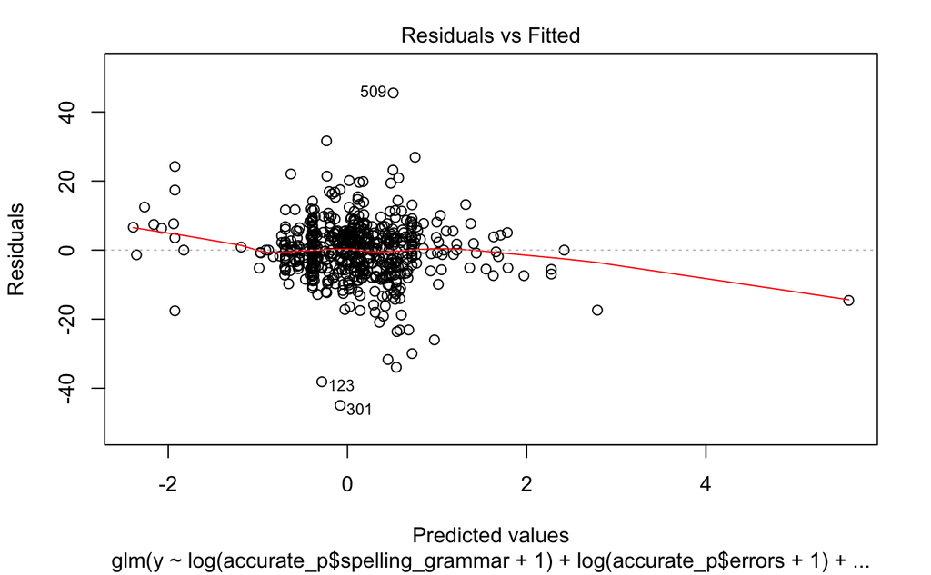

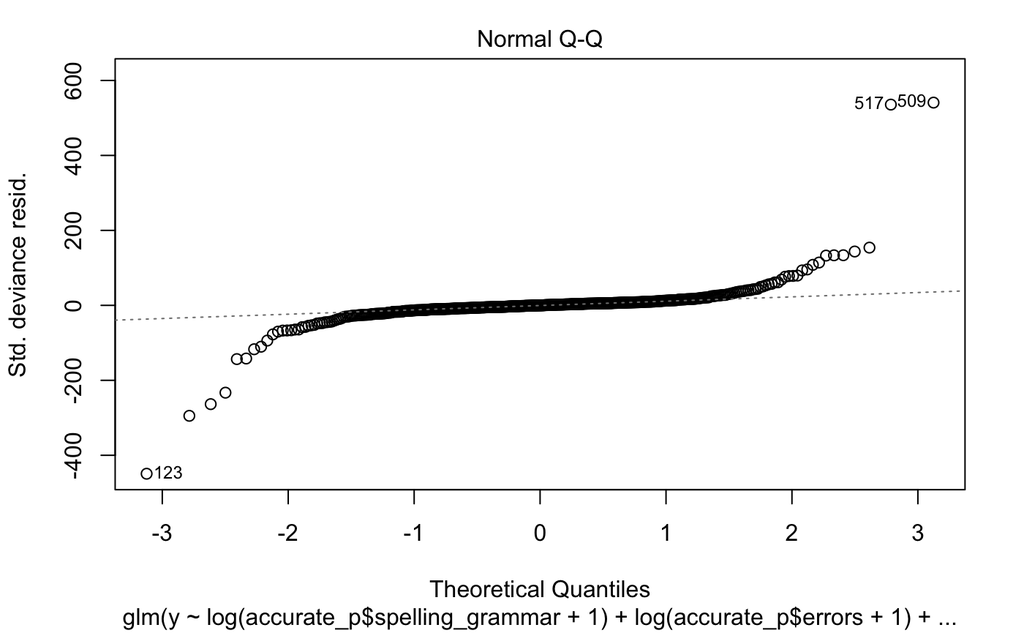

```
not plotting observations with leverage one:
  1, 161, 169, 186, 291, 334, 336, 432, 473, 488, 524, 545
```

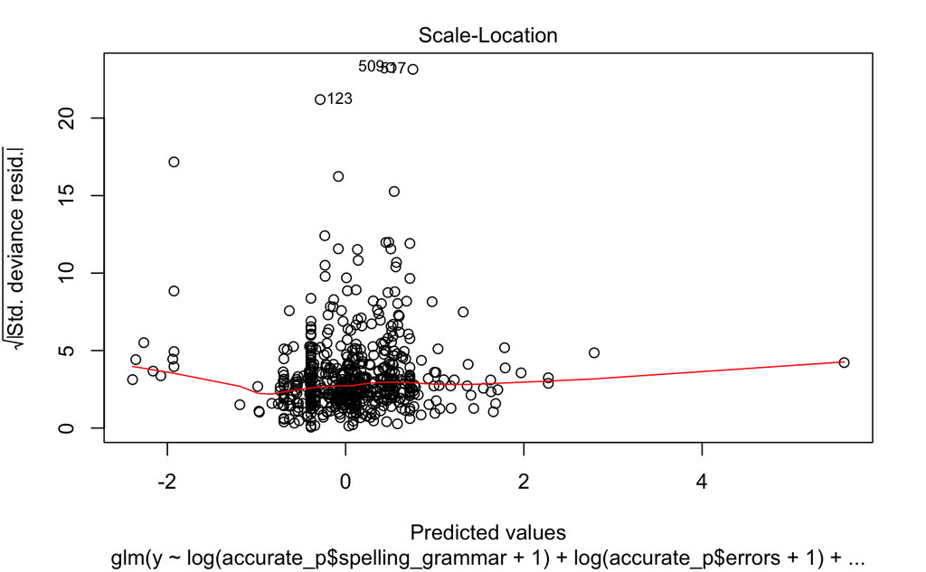

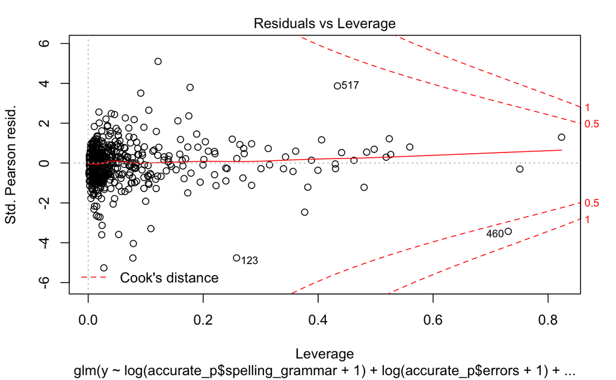

```r
plot(model3)
```

```r
plot_model(model3)
```

```
Error in plot_model(model3) : could not find function "plot_model"
```

```r
model4 <- glm(y~accurate_p$readability_score+
                accurate_p$contractions_count+
                accurate_p$equality_count+
                accurate_p$indefinite_article_count+
                accurate_p$passive_count+
                accurate_p$profanities_count+
                accurate_p$redundant_acronyms_count+
                accurate_p$repeated_words_count+
                accurate_p$simplify_count+
                accurate_p$spell_count+
                log(accurate_p$string_length+1)+
                log(accurate_p$sentence_count+1)+
                log(accurate_p$word_count+1),
              family='quasibinomial')
summary(model4)
```

```
Call:
glm(formula = y ~ accurate_p$readability_score + accurate_p$contractions_count +
    accurate_p$equality_count + accurate_p$indefinite_article_count +
    accurate_p$passive_count + accurate_p$profanities_count +
    accurate_p$redundant_acronyms_count + accurate_p$repeated_words_count +
    accurate_p$simplify_count + accurate_p$spell_count + log(accurate_p$string_length +
    1) + log(accurate_p$sentence_count + 1) + log(accurate_p$word_count +
    1), family = "quasibinomial")

Deviance Residuals:
    Min       1Q   Median       3Q      Max
-46.785   -5.973   -0.294    4.474   59.444

Coefficients:
                                     Estimate Std. Error t value Pr(>|t|)
(Intercept)                          4.798347   0.695650   6.898 1.83e-11 ***
accurate_p$readability_score        -0.004291   0.001169  -3.669 0.000273 ***
accurate_p$contractions_count       -0.147186   0.036830  -3.996 7.53e-05 ***
accurate_p$equality_count           -0.011770   0.034059  -0.346 0.729818
accurate_p$indefinite_article_count -0.150136   0.615175  -0.244 0.807302
accurate_p$passive_count            -0.027424   0.029218  -0.939 0.348451
accurate_p$profanities_count         0.025795   0.009629   2.679 0.007663 **
accurate_p$redundant_acronyms_count  1.324308   1.487612   0.890 0.373829
accurate_p$repeated_words_count     -0.133565   0.088544  -1.508 0.132149
accurate_p$simplify_count           -0.006169   0.011220  -0.550 0.582748
accurate_p$spell_count              -0.010738   0.003541  -3.033 0.002566 **
log(accurate_p$string_length + 1)   -2.478145   0.376713  -6.578 1.34e-10 ***
log(accurate_p$sentence_count + 1)   0.742030   0.171318   4.331 1.84e-05 ***
log(accurate_p$word_count + 1)       2.217970   0.382210   5.803 1.24e-08 ***
---
Signif. codes:  0 ‘***’ 0.001 ‘**’ 0.01 ‘*’ 0.05 ‘.’ 0.1 ‘ ’ 1

(Dispersion parameter for quasibinomial family taken to be 87.26073)

    Null deviance: 51675  on 456  degrees of freedom
Residual deviance: 39439  on 443  degrees of freedom
  (118 observations deleted due to missingness)
AIC: NA

Number of Fisher Scoring iterations: 5
```

```r
model5 <- glm(y~log(accurate_p$spelling_grammar+1)+
                log(accurate_p$errors+1)+
                log(accurate_p$style+1)+
                log(accurate_p$number_of_pdfs+1)+
                log(accurate_p$number_of_word_files+1)+
                log(accurate_p$string_length+1)+
                log(accurate_p$sentence_count+1)+
                log(accurate_p$word_count+1),
              quasibinomial)
summary(model5)
```

[output not shown]

```r
model6 <- glm(y~log(accurate_p$readability_score_scaled+1)+
                log(accurate_p$contractions_count_scaled+1)+
                log(accurate_p$equality_count_scaled+1)+
                log(accurate_p$indefinite_article_count_scaled+1)+
                log(accurate_p$passive_count_scaled+1)+
                log(accurate_p$profanities_count_scaled+1)+
                log(accurate_p$redundant_acronyms_count_scaled+1)+
                log(accurate_p$repeated_words_count_scaled+1)+
                log(accurate_p$simplify_count_scaled+1)+
                log(accurate_p$spell_count_scaled+1)+
                log(accurate_p$string_length+1)+
                log(accurate_p$sentence_count+1)+
                log(accurate_p$word_count+1),
              family='quasibinomial')
summary(model6)
```

```
Call:
glm(formula = y ~ log(accurate_p$readability_score_scaled + 1) +
    log(accurate_p$contractions_count_scaled + 1) + log(accurate_p$equality_count_scaled +
    1) + log(accurate_p$indefinite_article_count_scaled + 1) +
    log(accurate_p$passive_count_scaled + 1) + log(accurate_p$profanities_count_scaled +
    1) + log(accurate_p$redundant_acronyms_count_scaled + 1) +
    log(accurate_p$repeated_words_count_scaled + 1) + log(accurate_p$simplify_count_scaled +
    1) + log(accurate_p$spell_count_scaled + 1) + log(accurate_p$string_length +
    1) + log(accurate_p$sentence_count + 1) + log(accurate_p$word_count +
    1), family = "quasibinomial")

Deviance Residuals:
    Min       1Q   Median       3Q      Max
-69.600   -6.148   -0.617    4.067   57.670

Coefficients:
                                                      Estimate Std. Error t value Pr(>|t|)
(Intercept)                                           -0.06175    0.14639  -0.422  0.67332
log(accurate_p$readability_score_scaled + 1)           4.09469   13.09383   0.313  0.75461
log(accurate_p$contractions_count_scaled + 1)        -11.64842    8.53082  -1.365  0.17266
log(accurate_p$equality_count_scaled + 1)            -16.89930   22.09244  -0.765  0.44463
log(accurate_p$indefinite_article_count_scaled + 1)   -1.63737   21.38665  -0.077  0.93900
log(accurate_p$passive_count_scaled + 1)              -6.91183    6.95237  -0.994  0.32057
log(accurate_p$profanities_count_scaled + 1)          23.80447    8.62845   2.759  0.00599 **
log(accurate_p$redundant_acronyms_count_scaled + 1)    9.88288   12.03860   0.821  0.41203
log(accurate_p$repeated_words_count_scaled + 1)       -4.37735    5.27245  -0.830  0.40676
log(accurate_p$simplify_count_scaled + 1)            -10.54933   12.32767  -0.856  0.39250
log(accurate_p$spell_count_scaled + 1)              -105.52663   36.53320  -2.889  0.00402 **
log(accurate_p$string_length + 1)                     -0.07444    0.16920  -0.440  0.66015
log(accurate_p$sentence_count + 1)                     0.41850    0.17919   2.335  0.01987 *
log(accurate_p$word_count + 1)                         0.04869    0.24459   0.199  0.84228
---
Signif. codes:  0 ‘***’ 0.001 ‘**’ 0.01 ‘*’ 0.05 ‘.’ 0.1 ‘ ’ 1

(Dispersion parameter for quasibinomial family taken to be 103.9367)

    Null deviance: 72824  on 574  degrees of freedom
Residual deviance: 62060  on 561  degrees of freedom
AIC: NA

Number of Fisher Scoring iterations: 4
```